# final_project_censusdata

#Use tidycensus package to pull data from US Census Bureau to see how City of Columbia has changed over the past decade (2011 - 2020) # Source: Kyle Walker’s tidycensus: https://github.com/walkerke/tidycensus and his book: https://walker-data.com/census-r/. I can still have a lot of things to learn from this guy and the book. #Special thanks to Liz Lucas who has introduced me to R and MaryJo Webster who has introduced me to Kyle Walker.

```r
library(tidycensus)
library(tidyverse)
library(ggplot2)
library(tigris)
library(sf)
library(tmap)
library(leaflet)
library(ggiraph)
library(patchwork)
library(shiny)
```

# Load Variables to refer

```r
vars_2020 <- load_variables(2020, "acs5", cache = FALSE) #American Comunity Survey 5 years variable
vars_2015 <- load_variables(2015, "acs5", cache = FALSE)
vars_2010 <- load_variables(2010, "acs5", cache = FALSE)

den_2010 <- load_variables(2010, "pl", cache = FALSE) #decenial variables 2010
```

#Load profile variables

```r
profile_2020 <- load_variables(2020, "acs5/profile")
profile_2019 <- load_variables(2019, "acs5/profile")
profile_2018 <- load_variables(2018, "acs5/profile")
profile_2016 <- load_variables(2016, "acs5/profile")
profile_2015 <- load_variables(2015, "acs5/profile")
profile_2010 <- load_variables(2010, "acs5/profile")
```

#compare profile variables (new function of tidycensus package)

```r
compare_profile_2020 <- load_variables(2020, "acs5/cprofile")
compare_profile_2015 <- load_variables(2015, "acs5/cprofile")
```

#Total population 2011 - 2020. Geography = “place” (refer to “vars_x” file for varialbes ) #Variable: B01001_001 Estimate!!Total:

```r
years <- c(2011:2020)

total_population <- map_dfr(years, function(year) {
  get_acs(
  geography = "place",
  variables = c(total_population = "B01001_001"),
  state = "MO",
  year = year) %>%
    mutate(year = year)
}) %>%
  filter(grepl("Columbia", NAME))

write_csv(total_population, "total_population.csv")

#Columbia population ranking among cities in the U.S
#Ranked: 238
pop_rank <- get_acs(
  geography = "place",
  variables = "B01001_001",
  year = 2020
) %>% arrange(desc(estimate))
```

#Median age (“vars_x” datafile) #Variable: B01002_001 Estimate!!Median age –!!Total:

```r
years <- c(2011:2020)

median_age <- map_dfr(years, function(year) {
  get_acs(
  geography = "place",
  variables = c(median_age = "B01002_001"),
  state = "MO",
  year = year) %>%
    mutate(year = year)
})

#Columbia median age 2011:2020
columbia_median_age <- median_age %>% filter(grepl("Columbia", NAME))

write_csv(columbia_median_age, "data/columbia_median_age.csv")

#Ranked 2203/31908 "places" in the State in 2020
median_age_rank <- get_acs(
  geography = "place",
  variables = "B01002_001",
  year = 2020
) %>% arrange(estimate)

#Ranked 83/1082 place of MO
median_age_rank_mo <- get_acs(
  geography = "place",
  state = "MO",
  variables = "B01002_001",
  year = 2020
) %>% arrange(estimate)
```

#Columbia population pyramid 2010 - 2015 - 2020 to see how the population components have changed. #Load subject variables

```r
subject_2010 <- load_variables(2010, "acs5/subject")
```

```r
#Variables S0101_C03_0xx are female variables with different age groups. 2:19 are the values to paste in xx position, as age groups

cohort_names <- c("0-4", "5-9", "10-14", "15-19",
                  "20-24", "25-29", "30-34", "35-39",
                  "40-44", "45-49", "50-54", "55-59",
                  "60-64", "65-69", "70-74", "75-79",
                  "80-84", "85+")

female_vars <- 2:19 %>%
  str_pad(2, "left", "0") %>%
  paste0("S0101_C03_0", .) %>%
  set_names(cohort_names)

#Variables S0101_C02_0xx are male variables with different age groups

male_vars <- 2:19 %>%
  str_pad(2, "left", "0") %>%
  paste0("S0101_C02_0", .) %>%
  set_names(cohort_names)
```

```r
#2010
male_data_2010 <- get_acs(
  geography = "place",
  state = "MO",
  variables = male_vars,
  year = 2010
) %>% filter(grepl("Columbia", NAME)) %>% #Filter Columbia population
  mutate(NAME = str_remove(NAME, " city, Missouri")) %>% #Remove unnecessary words to clean the data
  mutate(sex = "Male",
         estimate = estimate * -1) #-1 to make male chart on the opposite side of female


female_data_2010 <- get_acs(
  geography = "place",
  state = "MO",
  variables = female_vars,
  year = 2010
) %>% filter(grepl("Columbia", NAME)) %>%
  mutate(NAME = str_remove(NAME, " city, Missouri")) %>%
  mutate(sex = "Female")

pyramid_2010 <- bind_rows(male_data_2010, female_data_2010)%>%
  mutate(variable = factor(variable, levels = cohort_names))

write_csv(pyramid_2010, "data/pyramid_2010.csv")
```

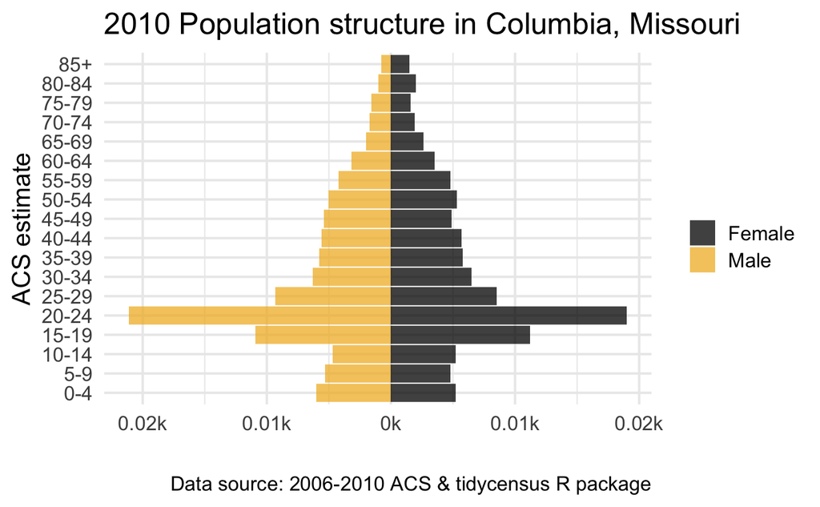

```r
#Visualize it by ggplot2
ggplot(pyramid_2010,
       aes(x = estimate,
           y = variable,
           fill = sex)) +
  geom_col(width = 0.95, alpha = 0.75) +
  theme_minimal(base_size = 16) +
  scale_x_continuous(labels = function(x) paste0(abs(x / 1000), "k")) +
  scale_fill_manual(values = c("#000000", "#F1B82D")) + #I choose Mizzou's colors
  labs(x = "",
       y = "ACS estimate",
       title = "2010 Population structure in Columbia, Missouri",
       fill = "",
       caption = "Data source: 2006-2010 ACS & tidycensus R package") #Credit

ggsave(filename = "pyramid2010.png",
       path = "maps",
       width = 8,
       height = 5,
       units = "in",
       dpi = 300)
```

```r
#2015

subject_2015 <- load_variables(2015, "acs5/subject")

cohort_names <- c("0-4", "5-9", "10-14", "15-19",
                  "20-24", "25-29", "30-34", "35-39",
                  "40-44", "45-49", "50-54", "55-59",
                  "60-64", "65-69", "70-74", "75-79",
                  "80-84", "85+")

female_vars <- 2:19 %>%
  str_pad(2, "left", "0") %>%
  paste0("S0101_C03_0", .) %>%
  set_names(cohort_names)

male_vars <- 2:19 %>%
  str_pad(2, "left", "0") %>%
  paste0("S0101_C02_0", .) %>%
  set_names(cohort_names)

male_data_2015 <- get_acs(
  geography = "place",
  state = "MO",
  variables = male_vars,
  year = 2015
) %>% filter(grepl("Columbia", NAME)) %>%
  mutate(NAME = str_remove(NAME, " city, Missouri")) %>%
  mutate(sex = "Male",
         estimate = estimate * -1)


female_data_2015 <- get_acs(
  geography = "place",
  state = "MO",
  variables = female_vars,
  year = 2015
) %>% filter(grepl("Columbia", NAME)) %>%
  mutate(NAME = str_remove(NAME, " city, Missouri")) %>%
  mutate(sex = "Female")

pyramid_2015 <- bind_rows(male_data_2015, female_data_2015)%>% #rbind the data
  mutate(variable = factor(variable, levels = cohort_names))

write_csv(pyramid_2015, "data/pyramid_2015.csv")
```

```r
pop_pyramid_2015 <- ggplot(pyramid_2015,
       aes(x = estimate,
           y = variable,
           fill = sex)) +
  geom_col(width = 0.95, alpha = 0.75) +
  theme_minimal(base_size = 16) +
  scale_x_continuous(labels = function(x) paste0(abs(x / 1000), "k")) +
  scale_fill_manual(values = c("#000000", "#F1B82D")) +
  labs(x = "",
       y = "ACS estimate",
       title = "2015 Population structure in Columbia, Missouri",
       fill = "",
       caption = "Data source: 2011-2015 ACS & tidycensus R package")


ggsave(filename = "pop_pyramid_2015.png",
       path = "maps",
       width = 8,
       height = 5,
       units = "in",
       dpi = 300)
```

```r
#2020

subject_2020 <- load_variables(2020, "acs5/subject")

cohort_names <- c("0-4", "5-9", "10-14", "15-19",
                  "20-24", "25-29", "30-34", "35-39",
                  "40-44", "45-49", "50-54", "55-59",
                  "60-64", "65-69", "70-74", "75-79",
                  "80-84", "85+")

male_vars <- 2:19 %>%
  str_pad(2, "left", "0") %>%
  paste0("S0101_C03_0", .) %>%
  set_names(cohort_names)

female_vars <- 2:19 %>%
  str_pad(2, "left", "0") %>%
  paste0("S0101_C05_0", .) %>%
  set_names(cohort_names)

male_data_2020 <- get_acs(
  geography = "place",
  state = "MO",
  variables = male_vars,
  year = 2020
) %>% filter(grepl("Columbia", NAME)) %>%
  mutate(NAME = str_remove(NAME, " city, Missouri")) %>%
  mutate(sex = "Male",
         estimate = estimate * -1)


female_data_2020 <- get_acs(
  geography = "place",
  state = "MO",
  variables = female_vars,
  year = 2020
) %>% filter(grepl("Columbia", NAME)) %>%
  mutate(NAME = str_remove(NAME, " city, Missouri")) %>%
  mutate(sex = "Female")

pyramid_2020 <- bind_rows(male_data_2020, female_data_2020)%>%
  mutate(variable = factor(variable, levels = cohort_names))

write_csv(pyramid_2020, "data/pyramid_2020.csv")
```

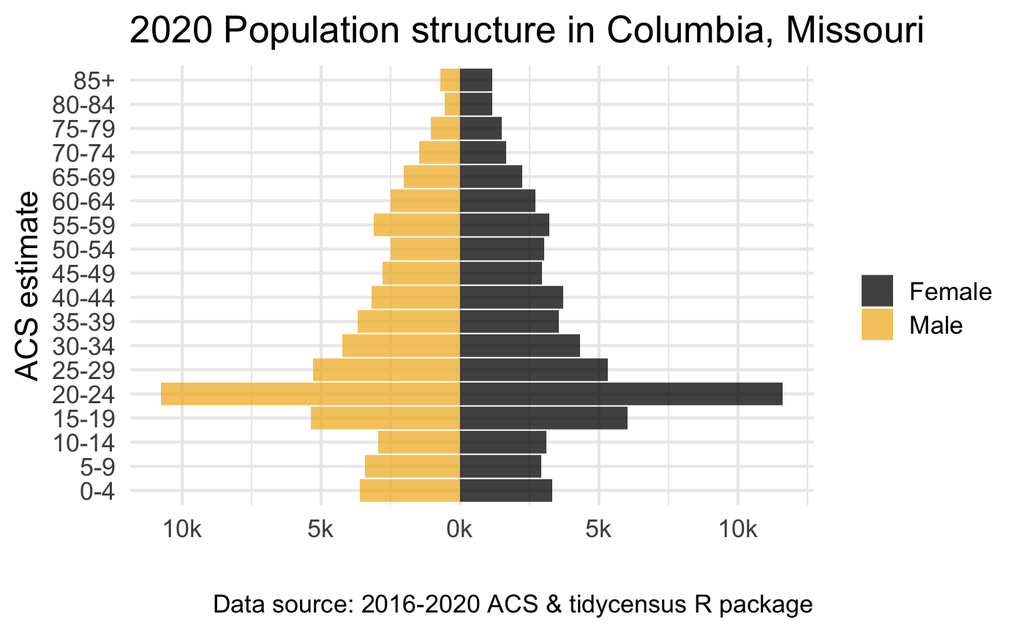

```r
ggplot(pyramid_2020,
       aes(x = estimate,
           y = variable,
           fill = sex)) +
  geom_col(width = 0.95, alpha = 0.75) +
  theme_minimal(base_size = 16) +
  scale_x_continuous(labels = function(x) paste0(abs(x / 1000), "k")) +
  scale_fill_manual(values = c("#000000", "#F1B82D")) +
  labs(x = "",
       y = "ACS estimate",
       title = "2020 Population structure in Columbia, Missouri",
       fill = "",
       caption = "Data source: 2016-2020 ACS & tidycensus R package")


ggsave(filename = "columbia_pyramid_2020.png",
       path = "maps",
       width = 8,
       height = 5,
       units = "in",
       dpi = 300)
```

#Columbia population is getting slightly older, but it hasn’t changed much the last decade. As a college town, young students have claimed a large part of the city’s population and contribute not not much change population’s structure.

#Median income #B19013_001 Estimate!!Median household income in the past 12 months

```r
years <- c(2011:2020)

median_income <- map_dfr(years, function(year) {
  get_acs(
  geography = "place",
  variables = c(median_income = "B19013_001"),
  state = "MO",
  year = year) %>%
    mutate(year = year)
})

columbia_median_income <- median_income %>% filter(grepl("Columbia", NAME))

write_csv(columbia_median_income, "data/columbia_median_income.csv")

#Ranked 14525/31908 places in the US, but the ranking doesn't mean much, since the estimate value for
#small geography level like place has large margin of error (especially with the places that have small sample size)
median_income_rank <- get_acs(
  geography = "place",
  variables = "B19013_001",
  year = 2020
) %>% arrange(desc(estimate))

#Ranked 310/1082 places of MO
median_income_rank_mo <- get_acs(
  geography = "place",
  state = "MO",
  variables = "B19013_001",
  year = 2020
) %>% arrange(desc(estimate))
```

#Poverty rate

```r
#Missouri's cities poverty rate in 2020: to see where Columbia is
#("vars_x" file)
#B17010_002: Estimate!!Total:!!Income in the past 12 months below poverty level (Concept: POVERTY STATUS IN THE PAST 12 MONTHS OF FAMILIES BY FAMILY TYPE BY PRESENCE OF RELATED CHILDREN UNDER 18 YEARS BY AGE OF RELATED CHILDREN)

#B17010_001: Estimate!!Total: (Concept: POVERTY STATUS IN THE PAST 12 MONTHS OF FAMILIES BY FAMILY TYPE BY PRESENCE OF RELATED CHILDREN UNDER 18 YEARS BY AGE OF RELATED CHILDREN)

mo_poverty <- get_acs(
  geography = "place",
  variables = c(poverty_num = "B17010_002",
                poverty_denom = "B17010_001"),
  state = "MO",
  year = 2020,
  output = "wide"
) %>% filter(grepl("city", NAME)) %>%
  mutate(percent = (poverty_numE/poverty_denomE)*100) %>%
  arrange(desc(percent))

#Because there are alot of small cities, I'll filter places where poverty_denomE is bigger than 20,000
mo_bigcity_poverty_2020 <- mo_poverty %>% filter(poverty_denomE > 20000)

#Columbia is 3/8 among big cities in Missouri in term of lowest poverty percent (8.5%)
```

#Let’s see how poverty percent of Columbia has changed the last decade

[figure not shown]

```r
#I think it makes sense more if compare Columbia to Missouri's Cosmopolitan Area
mo_cbsa_poverty <- get_acs(
    geography = "cbsa",
    variables = c(poverty_num = "B17010_002",
                  poverty_denom = "B17010_001"),
    year = 2020,
    output = "wide"
  ) %>%
  filter(grepl("MO", NAME) & grepl("Metro Area", NAME)) %>%
  mutate(percent = (poverty_numE/poverty_denomE)*100) %>%
  arrange(desc(percent))

#In 2020, Columbia ranked 5/8 of Missouri's Metro Area with 7.68% of poverty
```

```r
years <- c(2011:2020)

cbsa_10year_poverty <- map_dfr(years, function(year) {
  get_acs(
    geography = "cbsa",
    variables = c(poverty_num = "B17010_002",
                  poverty_denom = "B17010_001"),
    year = year,
    output = "wide"
  ) %>%
  mutate(year = year)
})
cbsa_10year_poverty %>% filter(grepl("MO", NAME) & grepl("Metro Area", NAME)) %>%
  mutate(percent = (poverty_numE/poverty_denomE)*100) %>%
  select(NAME, year, percent) %>%
  pivot_wider(names_from = year, values_from = percent)
```

| NAME | 2011 | 2012 | 2013 | 2014 | 2015 | 2016 | 2017 | 2018 | 2019 | 2020 |
| --- | --- | --- | --- | --- | --- | --- | --- | --- | --- | --- |
| Cape Girardeau-Jackson, MO-IL Metro Area | 11.522390 | 11.956957 | NA | NA | NA | NA | NA | NA | NA | NA |
| Columbia, MO Metro Area | 9.908948 | 9.628081 | 9.333191 | 9.311475 | 9.046685 | 9.270529 | 9.482126 | 9.152870 | 8.512812 | 7.687490 |
| Jefferson City, MO Metro Area | 7.711367 | 8.016238 | 8.942727 | 9.296128 | 8.863728 | 8.342347 | 8.474805 | 8.000107 | 7.630166 | 7.262674 |
| Joplin, MO Metro Area | 13.577752 | 13.142017 | 12.523936 | 11.595775 | 11.469030 | 11.686479 | 11.304614 | 11.766271 | 11.433638 | 11.326661 |
| Fayetteville-Springdale-Rogers, AR-MO Metro Area | 10.790423 | 11.255084 | 11.634047 | 11.377011 | 11.363145 | 10.634636 | 9.929089 | 9.634167 | NA | NA |
| St. Joseph, MO-KS Metro Area | 8.805439 | 9.320901 | 10.653033 | 12.001854 | 12.267413 | 12.325282 | 11.586618 | 11.284218 | 10.834657 | 9.864247 |
| St. Louis, MO-IL Metro Area | 9.004605 | 9.550958 | 9.765884 | 9.731384 | 9.590784 | 9.240250 | 8.791221 | 8.378125 | 7.861491 | 7.332208 |
| Springfield, MO Metro Area | 11.537223 | 12.059118 | 12.652866 | 12.293827 | 12.046430 | 11.641622 | 11.101213 | 10.414806 | 9.472514 | 9.107214 |
| Kansas City, MO-KS Metro Area | 8.243192 | 8.756057 | 8.944927 | 9.121369 | 9.075158 | 8.765580 | 8.099472 | 7.736230 | 7.428221 | 6.938123 |
| Cape Girardeau, MO-IL Metro Area | NA | NA | 12.017272 | 12.858911 | 13.140238 | 11.929943 | 11.837478 | 10.319222 | 9.720498 | 9.162463 |

# Education

#Note: Inconsistent variables (refer to profile series) (profile variables “profile_x” files) 2011-2018: DP02_0067: Estimate!!EDUCATIONAL ATTAINMENT!!Population 25 years and over!!Bachelor’s degree or higher DP02_0067P: Percent Estimate!!EDUCATIONAL ATTAINMENT!!Population 25 years and over!!Bachelor’s degree

2019-2020: DP02_0068: Estimate!!EDUCATIONAL ATTAINMENT!!Population 25 years and over!!Bachelor’s degree or higher DP02_0068P:Percent!!EDUCATIONAL ATTAINMENT!!Population 25 years and over!!Bachelor’s degree or higher

```r
years <- c(2010:2018)

education1 <- map_dfr(years, function(year) {
  get_acs(
    geography = "place",
    variables = c(percent = "DP02_0067P",
                  estimate = "DP02_0067"),
    state = "MO",
    year = year
  ) %>% mutate(year = year)
})

columbia_education1 <- education1 %>% filter(grepl("Columbia", NAME))

year1 <- c(2019:2020)

education2 <- map_dfr(year1, function(year) {
  get_acs(
    geography = "place",
    variables = c(percent = "DP02_0068P",
                  estimate = "DP02_0068"),
    state = "MO",
    year = year
  ) %>% mutate(year = year)
})

columbia_education2 <- education2 %>% filter(grepl("Columbia", NAME))

columbia_education <- bind_rows(columbia_education1, columbia_education2)

write_csv(columbia_education, "data/columbia_education.csv")

#Ranked 180/1082?
edu_rank <- get_acs(
    geography = "place",
    state = "MO",
    variables = "DP02_0067P",
    year = 2020) %>% arrange(desc(estimate))
```

#Unemployment

```r
#(profile variables "profile_x" files)
#DP03_0009P: Percent!!EMPLOYMENT STATUS!!Civilian labor force!!Unemployment Rate

years <- c(2010:2020)

unemployment <- map_dfr(years, function(year) {
  get_acs(
    geography = "place",
    variables = c(unemployment_rate = "DP03_0009P"),
    state = "MO",
    year = year
  ) %>% mutate(year = year)
})

columbia_unemployment <- unemployment %>% filter(grepl("Columbia", NAME))

write_csv(columbia_unemployment, "data/columbia_unemployment.csv")
```

#This data is to examine amount of people not in labor force

```r
#(profile variables)
#DP03_0007P Percent!!EMPLOYMENT STATUS!!Population 16 years and over!!Not in labor force
years <- c(2011:2020)

notin_laborforce <- map_dfr(years, function(year) {
  get_acs(
    geography = "place",
    variables = c(unemployment_rate = "DP03_0007P"),
    state = "MO",
    year = year
  ) %>% mutate(year = year)
}) %>% filter(grepl("Columbia", NAME))

write_csv(notin_laborforce, "notin_laborforce.csv")
```

#Compare race income

```r
mo_race_income <- get_acs(
  geography = "place",
  state = "MO",
  variables = c(White = "B03002_003",
                Black = "B03002_004",
                Asian = "B03002_006",
                Hispanic = "B03002_012"),
  summary_var = "B19013_001",
  year = 2020)
columbia_race_income <- mo_race_income %>% filter(grepl("Columbia", NAME))
```

#race 10 years income

```r
years <- c(2011:2020)

race_income_10year <- map_dfr(years, function(year) {
  get_acs(
  geography = "place",
  state = "MO",
  variables = c(White = "B19013A_001",
                Black = "B19013B_001",
                Asian = "B19013D_001",
                Hispanic = "B19013I_001"),
  summary_var = "B19013_001",
  year = year
  ) %>% mutate(year = year)
})

columbia_race_income_10year <- race_income_10year %>% filter(grepl("Columbia", NAME))

columbia_race_income_10year %>% filter(grepl("White", variable)) #just for checking

write_csv(columbia_race_income_10year, "data/columbia_race_income_10year.csv")
```

#Columbia race decennial (just to check)

```r
columbia_race_2020 <- get_decennial(
  geography = "place",
  state = "MO",
  variables = c(
    Hispanic = "P2_002N",
    White = "P2_005N",
    Black = "P2_006N",
    Native = "P2_007N",
    Asian = "P2_008N"
  ),
  summary_var = "P2_001N",
  year = 2020,
  geometry = TRUE
) %>%
  mutate(percent = 100 * (value / summary_value)) %>% filter(grepl("Columbia", NAME))
```

```
Downloading feature geometry from the Census website.  To cache shapefiles for use in future sessions, set `options(tigris_use_cache = TRUE)`.
Using the PL 94-171 Redistricting Data summary file
```

```
Note: 2020 decennial Census data use differential privacy, a technique that
introduces errors into data to preserve respondent confidentiality.
ℹ Small counts should be interpreted with caution.
ℹ See https://www.census.gov/library/fact-sheets/2021/protecting-the-confidentiality-of-the-2020-census-redistricting-data.html for additional guidance.
```

#Columbia map in 2011 and 2020 (places function is not currently available for years prior to 2011). Just to see how the city has changed geographically.

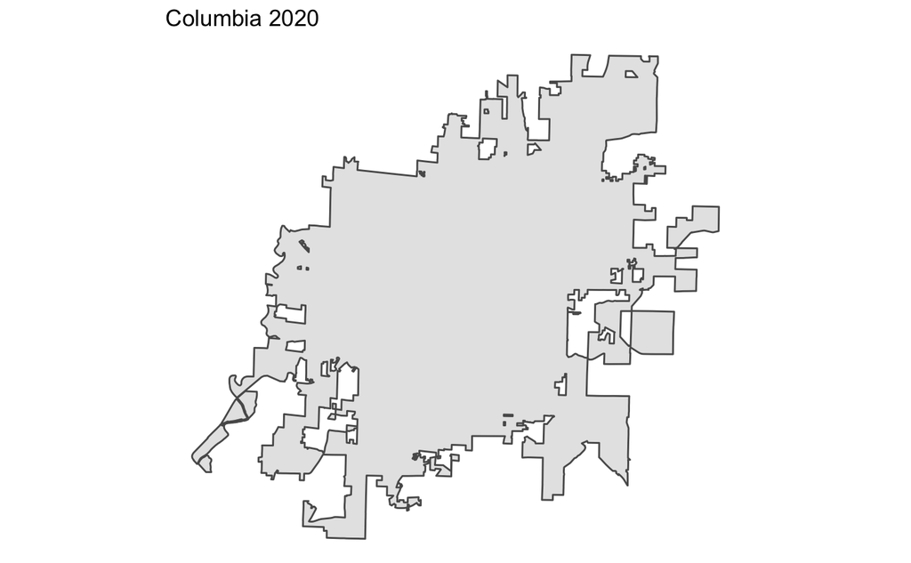

```r
mo_places <- places("MO", cb = FALSE, year = 2020)
columbia <- mo_places %>% filter(grepl("Columbia", NAME))

ggplot(columbia) +
  geom_sf() +
  theme_void() +
  labs(title = "Columbia 2020")
```

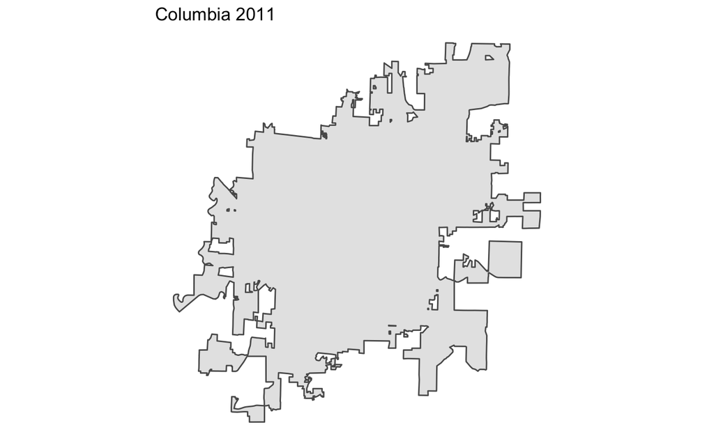

```r
mo_places_2011 <- places("MO", cb = FALSE, year = 2011)
columbia2011 <- mo_places_2011 %>% filter(grepl("Columbia", NAME))

ggplot(columbia2011) +
  geom_sf() +
  theme_void() +
  labs(title = "Columbia 2011")
```